# Assignment 3: Model comparison

Marton Kovacs (Resolved by David Kelemen)

In this lab assignment you are going to work with (simulated) data related to perioperative pain and its psychological and hormonal predictors. In the assignment you will assess the added benefit of including some psychological and hormonal predictors to the already established demographic predictors of pain.

In this assignment you will set up a hierarchical regression model to predict postoperative pain after wisdom tooth surgery.

# Research problem

The amount of pain experienced around and after surgeries are highly variable between and within individuals. In order to improve surgical pain management regimens we need to understand what influences pain around surgical procedures and predict the amount of pain an individual will experience.

Your first study in this area is related to assessing the influence of trait and state psychological measures on pain, and to see whether taking into account these variables can improve our understanding of postoperative pain.

# Procedures and measures

Use the data file called ‘assignment_3_dataset’, from the ‘data/’ folder.

You have collected data from 160 adults who were scheduled to undergo surgical extraction of the third mandibular molar (wisdom tooth surgery). Patients filled out a form in the waiting room before their surgery. The form contained questions about their sex, age, and weight, and psychological questionnaires assessing anxiety, pain catastrophizing, and mindfulness (see descriptions below). You also got blood samples and saliva samples from participants in the waiting room 5 minutes before their operations to determine the serum (a component of the blood) and salivary cortisol levels of participants. Participants were contacted 5 hours after the surgery to see how much pain they were experiencing. The **level of pain** at that moment was recorded using a numerical rating scale using a **scale of 0 to 10**, where 0 means “no pain” and 10 means “worst pain I can imagine”.

**The State Trait Anxiety Inventory:** T measures trait anxiety on a scale of 20 to 80, higher scores mean higher anxiety. Anxiety has been found in many studies to positively correlate with the level of pain experienced. This is **variable STAI_trait** in the dataset.

**The Pain Catastrophizing Scale** measures the extent of pain catastrophizing, which is characterized by a tendency to magnify the threat value of a pain stimulus and to feel helpless in the presence of pain, as well as by a relative inability to prevent or inhibit pain-related thoughts in anticipation of, during, or following a painful event. The total score on this scale ranges from 0 to 52, higher scores mean higher catastrophizing. Pain catastrophizing is one of the well-established predictors of clinical pain. This is **variable pain_cat** in the dataset.

**The Mindful Attention Awareness Scale (MAAS)** measures dispositional mindfulness, which may be described as a tendency to turn attention to present-moment experiences in an open, non-judgmental way. The MAAS total score ranges from 1 to 6 (an average of the item scores), with higher scores representing higher dispositional mindfulness. Trait mindfulness has been theorized to serve as a protective factor against pain, as the individual would be more objective about their pain experience and tend to associate less discomfort, despair, and hopelessness to the pain-related sensations. This is **variable mindfulness** in the dataset.

**Cortisol** is a stress hormone associated with acute and chronic stress. Cortisol levels are thought to be positively associated with pain experience. Cortisol can be **measured from both blood and the saliva**, although, serum cortisol is often regarded in medical research as more reliably related to stress (serum is a component of the blood plasma). These are **variables cortisol_serum**, and **cortisol_saliva** in the dataset.

# Research question

Previous studies and meta-analyses showed that age and sex are often predictors of pain (age is negatively associated with pain, while sex is a predictor more dependent on the type of the procedure). You would like to determine the extent to which taking into account psychological and hormonal variables aside from the already used demographic variables would improve our understanding of postoperative pain.

To answer this research question you will **need to compare two models** (with a hierarchical regression). The **simpler model** should contain **age and sex as predictors of pain**, while the **more complex model** should contain the **predictors: age, sex, STAI, pain catastrophizing, mindfulness, and cortisol measures**. Notice that the predictors used in the simpler model are a subset of the predictors used in more complex model. **You will have to do model comparison to assess whether substantial new information was gained about pain in the more complex model compared to the simpler model.**

# What to report

As usual, before you can interpret your model, you will need to run data and model diagnostics. First, check the variables included in the more complex model (age, sex, STAI, pain catastrophizing, mindfulness, and cortisol measures as predictors, and pain as an outcome) for **coding errors**, and the model itself for **influential outliers** (for example using Cook’s distance). Furthermore, check the final model to see if the **assumptions of linear regression hold true**, that is, **normality** (of the residuals), **linearity** (of the relationship), **homogeneity of variance** (also called homoscedasticity) and that there is no excess **multicollinearity** (“uncorrelated predictors” in Navarro’s words). If you find anything amiss during these checks, make the appropriate decision or correction and report your findings and actions in your report.

**Note:** If you do any changes, such as exclude cases, or exclude predictors from the model, you will have to re-run the above checks for your final data and model.

Report the results of the simpler model and the more complex model. For both models you should report the model test statistics (adj.R2, F, df, and p value). Also, report the statistics describing the coefficients of the predictors in a table format (unstandardized regression coefficients and 95% confidence intervals, standardized regression coefficients (B and Beta values), and p values).

Write up the regression equation of the more complex model in the form of 𝑌 = 𝑏0 + 𝑏1 ∗ X1 + 𝑏2 ∗ X2 +…+ bn * Xn, in which you use the actual regression coefficients of your models. (b0 stands for the intercept and b1, b2 … bn stand for the model coefficients for each of the predictors, and X1, X2, … Xn denote the predictors).

Compare the two models in terms of how much variance they explain of pain’s variability in the sample. Report Akaike information criterion (AIC) for both models and the F test statistic and p value of the likelihood ratio test comparing the two models.

# What to discuss

In your discussion of the findings, briefly interpret the results of the above analyses, and indicate whether you think that anything was gained by including the psychological and hormone measures in the model.

# Solution

## Read the data

Read the dataset used in this assignment. Pay attention to the extension of the datafile.

```r
options(repos = c(CRAN = "https://cran.rstudio.com/"))
library(broom)
library(car)
library(dplyr)
library(gridExtra)
library(lm.beta)
library(lmtest)
library(purrr)
library(readxl)
```

```r
print(getwd())
```

```
## [1] "C:/Users/kdawi/OneDrive/Dokumentumok/R-2024/assignments"
```

```r
data <- read_excel(file.path("C:/Users/kdawi/OneDrive/Dokumentumok/R-2024", "data", "assignment_3_dataset_.xlsx"))
data
```

```
## # A tibble: 160 × 12
##    ID     pain sex      age STAI_trait pain_cat cortisol_serum cortisol_saliva
##    <chr> <dbl> <chr>  <dbl>      <dbl>    <dbl>          <dbl>           <dbl>
##  1 ID_1      5 female    38         39       25           4.67            4.78
##  2 ID_2      4 female    36         46       31           6.01            6.71
##  3 ID_3      5 female    51         49       32           5.18            4.75
##  4 ID_4      7 female    39         48       41           6.65            6.68
##  5 ID_5      4 male      48         36       26           2.95            3.2
##  6 ID_6      6 female    45         37       28           4.32            4.36
##  7 ID_7      4 male      45         34       22           5.32            5.19
##  8 ID_8      5 female    35         39       32           5.26            5.53
##  9 ID_9      4 male      39         31       27           3.36            3.3
## 10 ID_10     5 female    33         38       36           5.96            5.78
## # ℹ 150 more rows
## # ℹ 4 more variables: mindfulness <dbl>, weight <dbl>, IQ <dbl>,
## #   household_income <dbl>
```

## Data and model diagnostics

### Data diagnostics

#### Descriptives of the variables

Run an exploratory data analysis (EDA) to investigate the dataset.

```r
str(data)
```

```
## tibble [160 × 12] (S3: tbl_df/tbl/data.frame)
##  $ ID              : chr [1:160] "ID_1" "ID_2" "ID_3" "ID_4" ...
##  $ pain            : num [1:160] 5 4 5 7 4 6 4 5 4 5 ...
##  $ sex             : chr [1:160] "female" "female" "female" "female" ...
##  $ age             : num [1:160] 38 36 51 39 48 45 45 35 39 33 ...
##  $ STAI_trait      : num [1:160] 39 46 49 48 36 37 34 39 31 38 ...
##  $ pain_cat        : num [1:160] 25 31 32 41 26 28 22 32 27 36 ...
##  $ cortisol_serum  : num [1:160] 4.67 6.01 5.18 6.65 2.95 4.32 5.32 5.26 3.36 5.96 ...
##  $ cortisol_saliva : num [1:160] 4.78 6.71 4.75 6.68 3.2 4.36 5.19 5.53 3.3 5.78 ...
##  $ mindfulness     : num [1:160] 3.83 2.82 3.93 1.9 4.39 3.01 4.97 2.95 3.43 1.85 ...
##  $ weight          : num [1:160] 62.1 97.1 79 78.5 76.9 ...
##  $ IQ              : num [1:160] 99 71 97 97 129 115 74 98 93 76 ...
##  $ household_income: num [1:160] 52505 64993 68598 47822 100580 ...
```

```r
summary(data)
```

```
##       ID                 pain            sex                 age
##  Length:160         Min.   : 1.000   Length:160         Min.   :24.00
##  Class :character   1st Qu.: 4.000   Class :character   1st Qu.:38.00
##  Mode  :character   Median : 5.000   Mode  :character   Median :41.00
##                     Mean   : 5.194                      Mean   :40.74
##                     3rd Qu.: 6.000                      3rd Qu.:44.00
##                     Max.   :50.000                      Max.   :53.00
##    STAI_trait       pain_cat     cortisol_serum  cortisol_saliva
##  Min.   :26.00   Min.   :14.00   Min.   :2.700   Min.   :2.530
##  1st Qu.:37.00   1st Qu.:27.00   1st Qu.:4.268   1st Qu.:4.120
##  Median :40.00   Median :30.00   Median :4.995   Median :5.035
##  Mean   :40.09   Mean   :29.88   Mean   :4.941   Mean   :4.952
##  3rd Qu.:43.00   3rd Qu.:32.25   3rd Qu.:5.633   3rd Qu.:5.753
##  Max.   :52.00   Max.   :42.00   Max.   :7.110   Max.   :7.190
##   mindfulness        weight            IQ         household_income
##  Min.   :1.000   Min.   :33.80   Min.   : 52.00   Min.   :  5548
##  1st Qu.:2.595   1st Qu.:62.15   1st Qu.: 91.75   1st Qu.: 53489
##  Median :3.115   Median :68.77   Median :101.00   Median : 72149
##  Mean   :3.204   Mean   :68.57   Mean   :100.74   Mean   : 70426
##  3rd Qu.:3.830   3rd Qu.:74.65   3rd Qu.:109.00   3rd Qu.: 87734
##  Max.   :6.220   Max.   :97.13   Max.   :144.00   Max.   :139268
```

```r
sum(is.na(data))
```

```
## [1] 0
```

```r
unique(data$sex)
```

```
## [1] "female" "male"   "woman"
```

#### Correct coding errors

If you find values in the dataset during the EDA, that are not correct based on the provided descriptions of the variables of the dataset please correct them here.

```r
valid_data_conditions_list <- list(
  0 <= data$pain & data$pain <= 10,
  20 <= data$STAI_trait & data$STAI_trait <= 80,
  0 <= data$pain_cat & data$pain_cat <= 52,
  1 <= data$mindfulness & data$mindfulness <= 6,
  18 <= data$age & data$age <= 100,
  0 <= data$cortisol_serum,
  0 <= data$cortisol_saliva,
  40 <= data$weight,
  0 <= data$household_income
)



valid_data_condition <- reduce(valid_data_conditions_list, `&`)
print("Incorrect values:")
```

```
## [1] "Incorrect values:"
```

```r
print(data[!valid_data_condition, ])
```

```
## # A tibble: 3 × 12
##   ID      pain sex      age STAI_trait pain_cat cortisol_serum cortisol_saliva
##   <chr>  <dbl> <chr>  <dbl>      <dbl>    <dbl>          <dbl>           <dbl>
## 1 ID_49      2 male      49         26       15           3.86            3.85
## 2 ID_82      3 female    48         36       26           3.61            3.35
## 3 ID_142    50 female    41         44       30           5.85            6.14
## # ℹ 4 more variables: mindfulness <dbl>, weight <dbl>, IQ <dbl>,
## #   household_income <dbl>
```

```r
valid_data <- data[valid_data_condition, ]

valid_data <- valid_data %>%
  mutate(sex = case_when( sex == "woman" ~ "female", TRUE ~ sex))


unique(valid_data$sex)
```

```
## [1] "female" "male"
```

```r
valid_data
```

```
## # A tibble: 157 × 12
##    ID     pain sex      age STAI_trait pain_cat cortisol_serum cortisol_saliva
##    <chr> <dbl> <chr>  <dbl>      <dbl>    <dbl>          <dbl>           <dbl>
##  1 ID_1      5 female    38         39       25           4.67            4.78
##  2 ID_2      4 female    36         46       31           6.01            6.71
##  3 ID_3      5 female    51         49       32           5.18            4.75
##  4 ID_4      7 female    39         48       41           6.65            6.68
##  5 ID_5      4 male      48         36       26           2.95            3.2
##  6 ID_6      6 female    45         37       28           4.32            4.36
##  7 ID_7      4 male      45         34       22           5.32            5.19
##  8 ID_8      5 female    35         39       32           5.26            5.53
##  9 ID_9      4 male      39         31       27           3.36            3.3
## 10 ID_10     5 female    33         38       36           5.96            5.78
## # ℹ 147 more rows
## # ℹ 4 more variables: mindfulness <dbl>, weight <dbl>, IQ <dbl>,
## #   household_income <dbl>
```

### Model diagnostics

#### Build the more complex model

In order to test the more complex model for outliers and to test the assumptions first build the model.

```r
model <- lm(pain ~ age + sex + STAI_trait + pain_cat + mindfulness + cortisol_serum + cortisol_saliva, data = valid_data)
summary(model)
```

```
##
## Call:
## lm(formula = pain ~ age + sex + STAI_trait + pain_cat + mindfulness +
##     cortisol_serum + cortisol_saliva, data = valid_data)
##
## Residuals:
##     Min      1Q  Median      3Q     Max
## -3.2367 -0.7547 -0.0605  0.7924  2.9327
##
## Coefficients:
##                 Estimate Std. Error t value Pr(>|t|)
## (Intercept)      1.32221    1.73541   0.762  0.44733
## age             -0.02065    0.02464  -0.838  0.40346
## sexmale          0.31405    0.21321   1.473  0.14286
## STAI_trait      -0.02884    0.02836  -1.017  0.31078
## pain_cat         0.09381    0.02898   3.237  0.00149 **
## mindfulness     -0.11970    0.12670  -0.945  0.34632
## cortisol_serum   0.16937    0.24650   0.687  0.49310
## cortisol_saliva  0.44291    0.25402   1.744  0.08330 .
## ---
## Signif. codes:  0 '***' 0.001 '**' 0.01 '*' 0.05 '.' 0.1 ' ' 1
##
## Residual standard error: 1.248 on 149 degrees of freedom
## Multiple R-squared:  0.3453, Adjusted R-squared:  0.3145
## F-statistic: 11.23 on 7 and 149 DF,  p-value: 2.253e-11
```

#### Checking for influential outliers

Check for outlier values in the model.

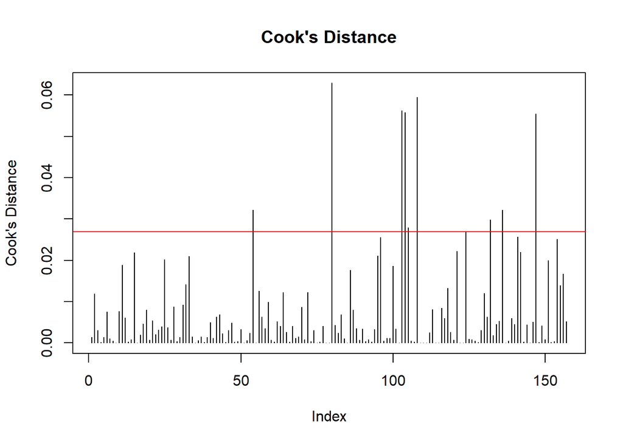

```r
cooksd <- cooks.distance(model)

# Plot Cook's Distance
plot(cooksd, type = "h", main = "Cook's Distance", ylab = "Cook's Distance")
threshold <- min(1, 4 / (nrow(valid_data) - length(model$coefficients)))
abline(h = threshold, col = "red")
```

```r
# Identify points with high Cook's Distance
influential <- which(cooksd > threshold)
print("Influential points based on Cook's Distance:")
```

```
## [1] "Influential points based on Cook's Distance:"
```

```r
print(influential)
```

```
##  54  80 103 104 105 108 124 132 136 147
##  54  80 103 104 105 108 124 132 136 147
```

```r
cleaned_data <- valid_data[-influential, ]

new_model <- lm(pain ~ age + sex + STAI_trait + pain_cat + mindfulness + cortisol_serum + cortisol_saliva, data = cleaned_data)
summary(new_model)
```

```
##
## Call:
## lm(formula = pain ~ age + sex + STAI_trait + pain_cat + mindfulness +
##     cortisol_serum + cortisol_saliva, data = cleaned_data)
##
## Residuals:
##      Min       1Q   Median       3Q      Max
## -2.77663 -0.71813 -0.04769  0.70039  2.58536
##
## Coefficients:
##                   Estimate Std. Error t value Pr(>|t|)
## (Intercept)      0.4898476  1.6041991   0.305  0.76055
## age             -0.0258543  0.0224977  -1.149  0.25245
## sexmale          0.3767699  0.1954698   1.928  0.05596 .
## STAI_trait      -0.0009841  0.0267854  -0.037  0.97074
## pain_cat         0.0932775  0.0282916   3.297  0.00124 **
## mindfulness     -0.0851115  0.1203073  -0.707  0.48047
## cortisol_serum  -0.0527550  0.2376247  -0.222  0.82463
## cortisol_saliva  0.6282260  0.2410400   2.606  0.01015 *
## ---
## Signif. codes:  0 '***' 0.001 '**' 0.01 '*' 0.05 '.' 0.1 ' ' 1
##
## Residual standard error: 1.096 on 139 degrees of freedom
## Multiple R-squared:  0.4277, Adjusted R-squared:  0.3989
## F-statistic: 14.84 on 7 and 139 DF,  p-value: 2.317e-14
```

#### Checking assumptions

Check the normality assumption.

```r
shapiro_test <- shapiro.test(residuals(new_model))
print(shapiro_test)
```

```
##
##  Shapiro-Wilk normality test
##
## data:  residuals(new_model)
## W = 0.99307, p-value = 0.7009
```

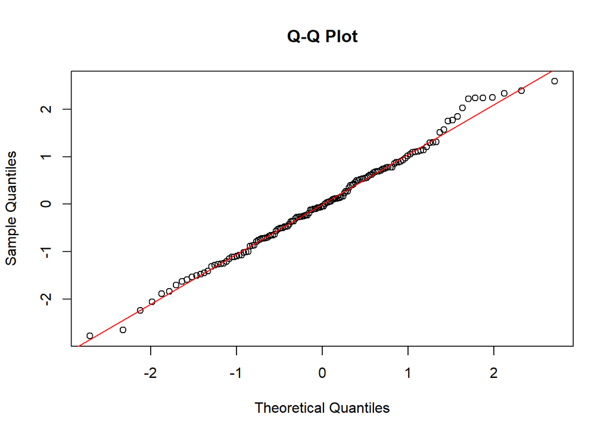

```r
qqnorm(residuals(new_model), main = "Q-Q Plot")
qqline(residuals(new_model), col = "red")
```

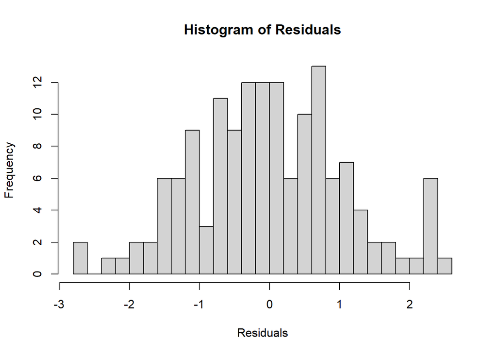

```r
hist(residuals(new_model), main = "Histogram of Residuals", xlab = "Residuals", breaks = 20)
```

Check the linearity assumption.

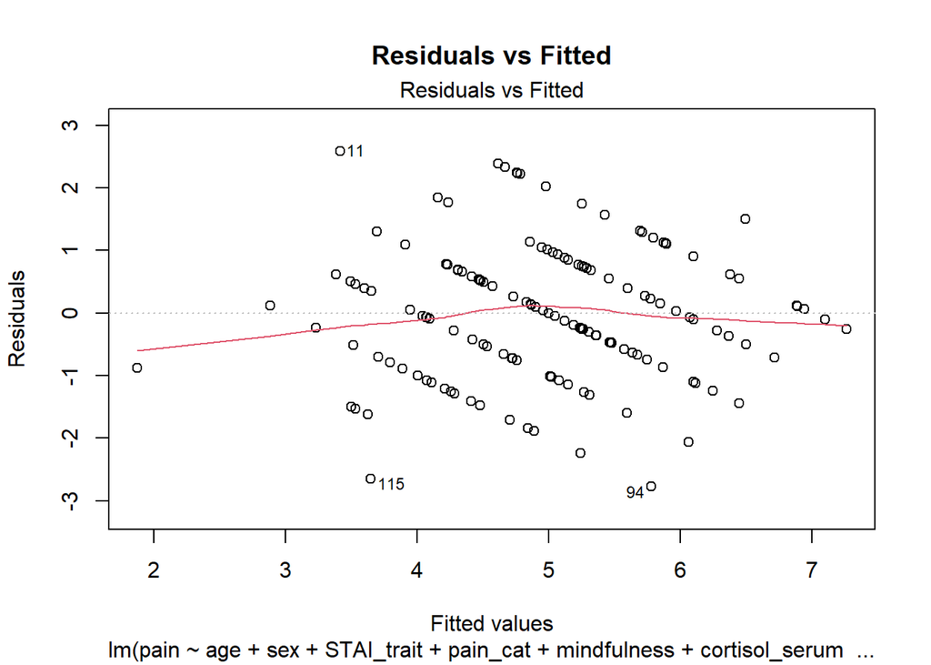

```r
plot(new_model, which = 1, main = "Residuals vs Fitted")
```

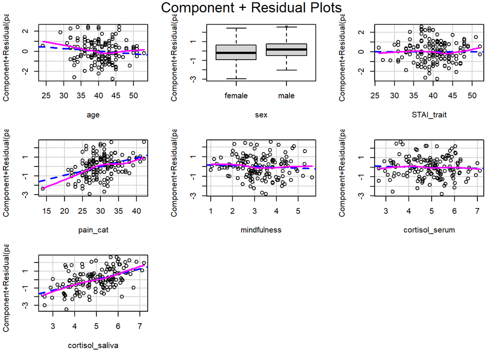

```r
crPlots(new_model)
```

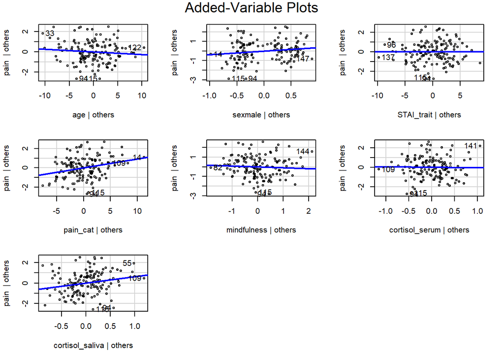

```r
avPlots(new_model)
```

Check the homoscedasticty assumption (homogeneity of variance).

```r
# Perform the Breusch-Pagan test
bp_test <- bptest(new_model)
print(bp_test)
```

```
##
##  studentized Breusch-Pagan test
##
## data:  new_model
## BP = 9.3622, df = 7, p-value = 0.2277
```

```r
# Perform the NCV test
ncv_test <- ncvTest(new_model)
print(ncv_test)
```

```
## Non-constant Variance Score Test
## Variance formula: ~ fitted.values
## Chisquare = 1.714978, Df = 1, p = 0.19034
```

Check the multicollinearity assumption.

(VIF above 5), or a VIF threshold of 3 is recommended in this paper: http://onlinelibrary.wiley.com/doi/10.1111/j.2041-210X.2009.00001.x/full

Some info about VIF: https://statisticalhorizons.com/multicollinearity http://blog.minitab.com/blog/understanding-statistics/handling-multicollinearity-in-regression-analysis

```r
vif_values <- vif(new_model)
print(vif_values)
```

```
##             age             sex      STAI_trait        pain_cat     mindfulness
##        1.563588        1.166984        2.213423        2.084990        1.575684
##  cortisol_serum cortisol_saliva
##        6.658834        7.148949
```

```r
high_vif <- vif_values[vif_values > 3]
print("Predictors with high VIF:")
```

```
## [1] "Predictors with high VIF:"
```

```r
print(high_vif)
```

```
##  cortisol_serum cortisol_saliva
##        6.658834        7.148949
```

```r
# cortisol_serum and cortisol_saliva whas >5 value - keep cortisol_saliva
# as this variable is significant in the model
```

### Making decision based on model diagnostics

If based on the assumption tests you decide to drop a predictor variable you should do that here. Create your updated model.

```r
updated_model <- lm(pain ~ age + sex + STAI_trait + pain_cat + mindfulness + cortisol_saliva, data = cleaned_data)
summary(updated_model)
```

```
##
## Call:
## lm(formula = pain ~ age + sex + STAI_trait + pain_cat + mindfulness +
##     cortisol_saliva, data = cleaned_data)
##
## Residuals:
##      Min       1Q   Median       3Q      Max
## -2.74820 -0.70985 -0.04482  0.70181  2.58883
##
## Coefficients:
##                   Estimate Std. Error t value Pr(>|t|)
## (Intercept)      0.5176159  1.5938761   0.325 0.745853
## age             -0.0264213  0.0222762  -1.186 0.237601
## sexmale          0.3786955  0.1946131   1.946 0.053671 .
## STAI_trait      -0.0005208  0.0266132  -0.020 0.984414
## pain_cat         0.0916175  0.0271928   3.369 0.000974 ***
## mindfulness     -0.0866716  0.1196933  -0.724 0.470204
## cortisol_saliva  0.5817903  0.1193933   4.873 2.94e-06 ***
## ---
## Signif. codes:  0 '***' 0.001 '**' 0.01 '*' 0.05 '.' 0.1 ' ' 1
##
## Residual standard error: 1.093 on 140 degrees of freedom
## Multiple R-squared:  0.4275, Adjusted R-squared:  0.4029
## F-statistic: 17.42 on 6 and 140 DF,  p-value: 5.389e-15
```

```r
updated_vif_values <- vif(updated_model)
print("VIF values for each predictor in the updated model:")
```

```
## [1] "VIF values for each predictor in the updated model:"
```

```r
print(updated_vif_values)
```

```
##             age             sex      STAI_trait        pain_cat     mindfulness
##        1.543440        1.164686        2.199988        1.939345        1.570308
## cortisol_saliva
##        1.765970
```

#### Checking outliers of the updated model

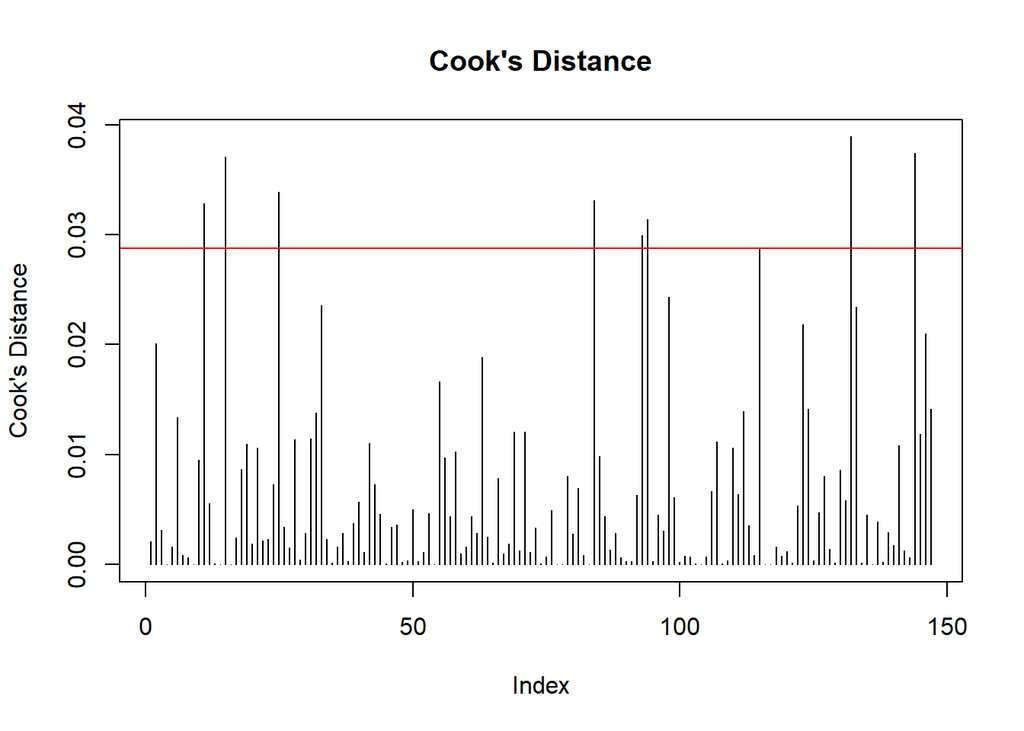

```r
cooksd <- cooks.distance(updated_model)

# Plot Cook's Distance
plot(cooksd, type = "h", main = "Cook's Distance", ylab = "Cook's Distance")
threshold <- 4 / (nrow(cleaned_data) - length(model$coefficients))
abline(h = threshold, col = "red")
```

```r
# Identify points with high Cook's Distance
influential <- which(cooksd > threshold)
print("Influential points based on Cook's Distance:")
```

```
## [1] "Influential points based on Cook's Distance:"
```

```r
print(influential)
```

```
##  11  15  25  84  93  94 115 132 144
##  11  15  25  84  93  94 115 132 144
```

```r
updated_data <- cleaned_data[-influential, ]

updated_model <- lm(pain ~ age + sex + STAI_trait + pain_cat + mindfulness + cortisol_saliva, data = updated_data)
summary(updated_model)
```

```
##
## Call:
## lm(formula = pain ~ age + sex + STAI_trait + pain_cat + mindfulness +
##     cortisol_saliva, data = updated_data)
##
## Residuals:
##      Min       1Q   Median       3Q      Max
## -2.18033 -0.64536 -0.04487  0.68767  2.42055
##
## Coefficients:
##                  Estimate Std. Error t value Pr(>|t|)
## (Intercept)      0.727328   1.455990   0.500 0.618236
## age             -0.023186   0.020206  -1.147 0.253289
## sexmale          0.377958   0.177099   2.134 0.034693 *
## STAI_trait      -0.001861   0.023664  -0.079 0.937449
## pain_cat         0.087683   0.024318   3.606 0.000441 ***
## mindfulness     -0.176446   0.111551  -1.582 0.116118
## cortisol_saliva  0.595574   0.113947   5.227 6.63e-07 ***
## ---
## Signif. codes:  0 '***' 0.001 '**' 0.01 '*' 0.05 '.' 0.1 ' ' 1
##
## Residual standard error: 0.9576 on 131 degrees of freedom
## Multiple R-squared:  0.5093, Adjusted R-squared:  0.4868
## F-statistic: 22.66 on 6 and 131 DF,  p-value: < 2.2e-16
```

#### Checking assumptions of the updated model

Normality assumption

```r
shapiro_test <- shapiro.test(residuals(updated_model))
print(shapiro_test)
```

```
##
##  Shapiro-Wilk normality test
##
## data:  residuals(updated_model)
## W = 0.99332, p-value = 0.7669
```

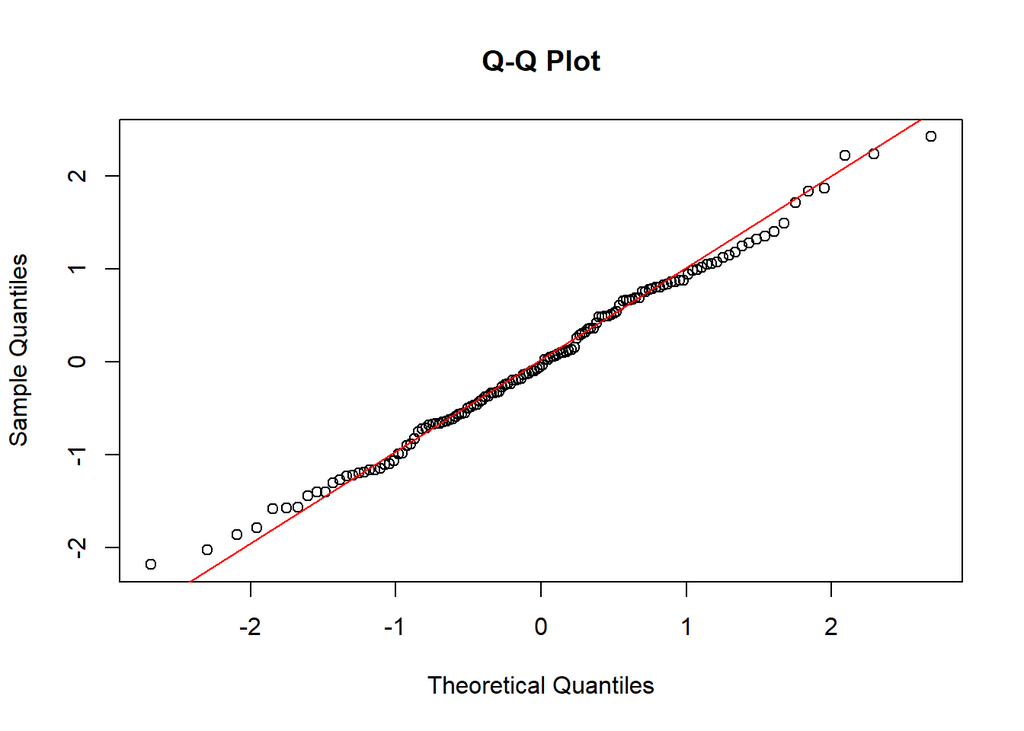

```r
qqnorm(residuals(updated_model), main = "Q-Q Plot")
qqline(residuals(updated_model), col = "red")
```

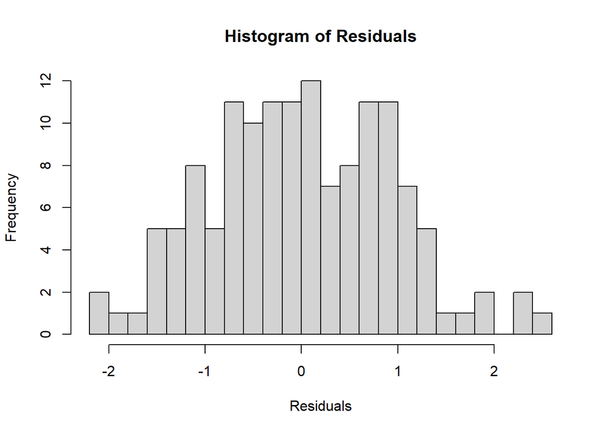

```r
hist(residuals(updated_model), main = "Histogram of Residuals", xlab = "Residuals", breaks = 20)
```

Linearity assumption

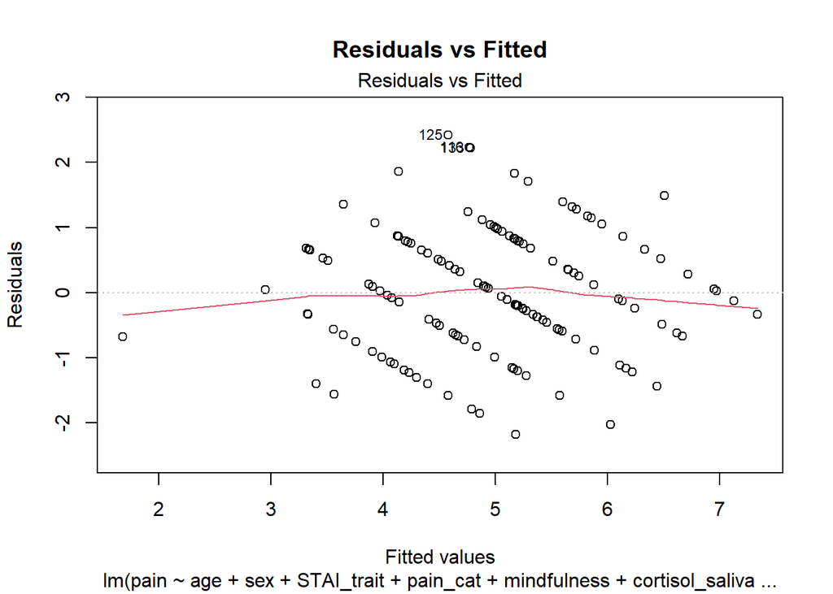

```r
plot(updated_model, which = 1, main = "Residuals vs Fitted")
```

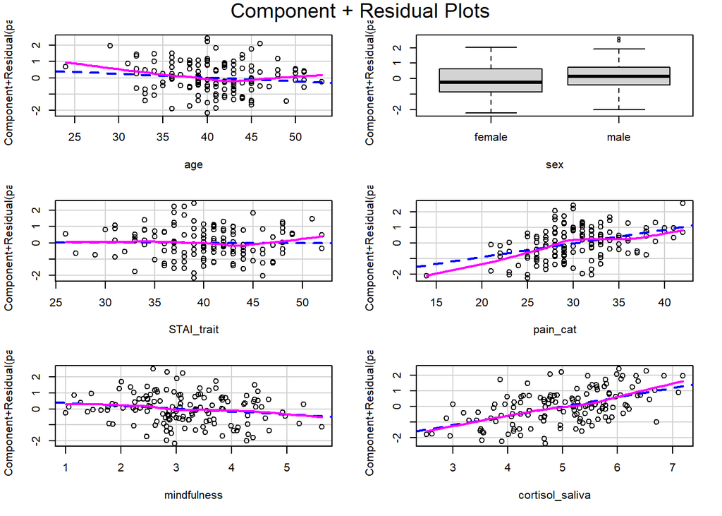

```r
crPlots(updated_model)
```

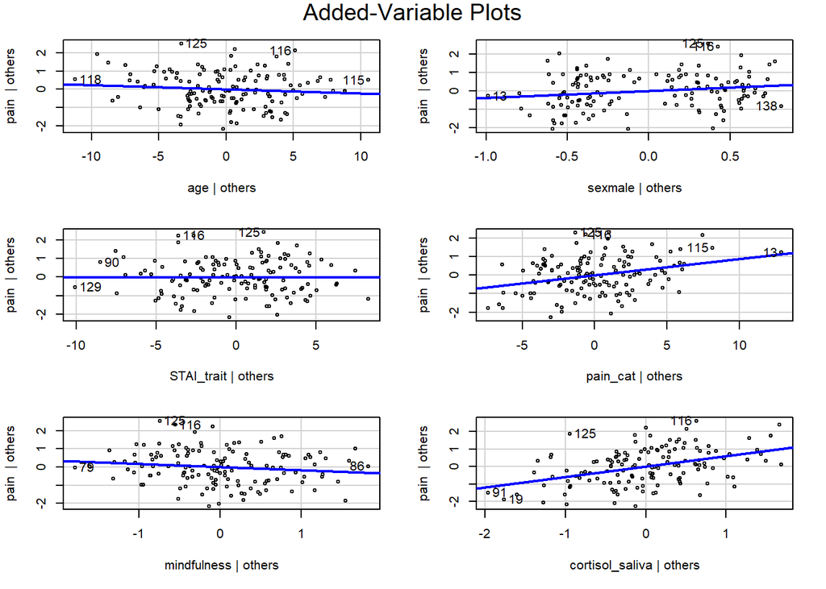

```r
avPlots(updated_model)
```

Homoscedasticty assumption (homogeneity of variance)

```r
# Perform the Breusch-Pagan test
bp_test <- bptest(updated_model)
print(bp_test)
```

```
##
##  studentized Breusch-Pagan test
##
## data:  updated_model
## BP = 1.987, df = 6, p-value = 0.9209
```

```r
# Perform the NCV test
ncv_test <- ncvTest(updated_model)
print(ncv_test)
```

```
## Non-constant Variance Score Test
## Variance formula: ~ fitted.values
## Chisquare = 0.03366585, Df = 1, p = 0.85442
```

Multicollinearity assumption

```r
vif_values <- vif(updated_model)
print(vif_values)
```

```
##             age             sex      STAI_trait        pain_cat     mindfulness
##        1.537782        1.179944        2.223081        1.966239        1.601531
## cortisol_saliva
##        1.865964
```

```r
high_vif <- vif_values[vif_values > 3]
print("Predictors with high VIF:")
```

```
## [1] "Predictors with high VIF:"
```

```r
print(high_vif)
```

```
## named numeric(0)
```

## Model comparison

Create the simple model and get the results of the model that needs to be reported based on the What to report section.

```r
simple_model <- lm(pain ~ age + sex, data = updated_data)
simple_summary <- summary(simple_model)
print(simple_summary)
```

```
##
## Call:
## lm(formula = pain ~ age + sex, data = updated_data)
##
## Residuals:
##     Min      1Q  Median      3Q     Max
## -3.7988 -0.8463  0.0388  0.8506  3.2824
##
## Coefficients:
##             Estimate Std. Error t value Pr(>|t|)
## (Intercept)  8.28951    0.89757   9.235 4.81e-16 ***
## age         -0.08118    0.02182  -3.720 0.000291 ***
## sexmale     -0.05364    0.21833  -0.246 0.806299
## ---
## Signif. codes:  0 '***' 0.001 '**' 0.01 '*' 0.05 '.' 0.1 ' ' 1
##
## Residual standard error: 1.282 on 135 degrees of freedom
## Multiple R-squared:  0.09366,    Adjusted R-squared:  0.08023
## F-statistic: 6.975 on 2 and 135 DF,  p-value: 0.00131
```

Create the more complex model based on the results of the model diagnostics. Also, get the results that needs to be reported based on the What to report section.

```r
complex_model <- lm(pain ~ age + sex + STAI_trait + pain_cat + mindfulness + cortisol_saliva, data = updated_data)
complex_summary <- summary(complex_model)
print(complex_summary)
```

```
##
## Call:
## lm(formula = pain ~ age + sex + STAI_trait + pain_cat + mindfulness +
##     cortisol_saliva, data = updated_data)
##
## Residuals:
##      Min       1Q   Median       3Q      Max
## -2.18033 -0.64536 -0.04487  0.68767  2.42055
##
## Coefficients:
##                  Estimate Std. Error t value Pr(>|t|)
## (Intercept)      0.727328   1.455990   0.500 0.618236
## age             -0.023186   0.020206  -1.147 0.253289
## sexmale          0.377958   0.177099   2.134 0.034693 *
## STAI_trait      -0.001861   0.023664  -0.079 0.937449
## pain_cat         0.087683   0.024318   3.606 0.000441 ***
## mindfulness     -0.176446   0.111551  -1.582 0.116118
## cortisol_saliva  0.595574   0.113947   5.227 6.63e-07 ***
## ---
## Signif. codes:  0 '***' 0.001 '**' 0.01 '*' 0.05 '.' 0.1 ' ' 1
##
## Residual standard error: 0.9576 on 131 degrees of freedom
## Multiple R-squared:  0.5093, Adjusted R-squared:  0.4868
## F-statistic: 22.66 on 6 and 131 DF,  p-value: < 2.2e-16
```

Compare the two models.

```r
# Extract key metrics for comparison
simple_r_squared <- simple_summary$r.squared
simple_adj_r_squared <- simple_summary$adj.r.squared
simple_f_statistic <- simple_summary$fstatistic
simple_residual_se <- simple_summary$sigma
simple_aic <- AIC(simple_model)
simple_bic <- BIC(simple_model)

complex_r_squared <- complex_summary$r.squared
complex_adj_r_squared <- complex_summary$adj.r.squared
complex_f_statistic <- complex_summary$fstatistic
complex_residual_se <- complex_summary$sigma
complex_aic <- AIC(complex_model)
complex_bic <- BIC(complex_model)

# Reporting the results
cat("Simple Model Summary:\n")
```

```
## Simple Model Summary:
```

```r
cat("R-squared:", simple_r_squared, "\n")
```

```
## R-squared: 0.09366139
```

```r
cat("Adjusted R-squared:", simple_adj_r_squared, "\n")
```

```
## Adjusted R-squared: 0.08023415
```

```r
cat("F-statistic:", simple_f_statistic[1], "on", simple_f_statistic[2], "and", simple_f_statistic[3], "DF, p-value:", pf(simple_f_statistic[1], simple_f_statistic[2], simple_f_statistic[3], lower.tail = FALSE), "\n")
```

```
## F-statistic: 6.975477 on 2 and 135 DF, p-value: 0.001309506
```

```r
cat("Residual Standard Error:", simple_residual_se, "\n")
```

```
## Residual Standard Error: 1.282038
```

```r
cat("AIC value:", simple_aic, "\n")
```

```
## AIC value: 465.1663
```

```r
cat("BIC value:", simple_bic, "\n\n")
```

```
## BIC value: 476.8754
```

```r
cat("Complex Model Summary:\n")
```

```
## Complex Model Summary:
```

```r
cat("R-squared:", complex_r_squared, "\n")
```

```
## R-squared: 0.5093
```

```r
cat("Adjusted R-squared:", complex_adj_r_squared, "\n")
```

```
## Adjusted R-squared: 0.4868252
```

```r
cat("F-statistic:", complex_f_statistic[1], "on", complex_f_statistic[2], "and", complex_f_statistic[3], "DF, p-value:", pf(complex_f_statistic[1], complex_f_statistic[2], complex_f_statistic[3], lower.tail = FALSE), "\n")
```

```
## F-statistic: 22.66093 on 6 and 131 DF, p-value: 3.357948e-18
```

```r
cat("Residual Standard Error:", complex_residual_se, "\n")
```

```
## Residual Standard Error: 0.9576235
```

```r
cat("AIC value:", complex_aic, "\n")
```

```
## AIC value: 388.4923
```

```r
cat("BIC value:", complex_bic, "\n\n")
```

```
## BIC value: 411.9103
```

```r
# Complex model explains 50% of the variance, simple model only 9%.
# AIC and BIC also show that complex model is better.
```

```r
# Unstandardized coefficients and confidence intervals
simple_coef <- tidy(simple_model, conf.int = TRUE)
complex_coef <- tidy(complex_model, conf.int = TRUE)


# Standardized coefficients
simple_std_coef <- lm.beta(simple_model)
complex_std_coef <- lm.beta(complex_model)

# Combine results into a data frame
simple_results <- simple_coef %>%
  mutate(Std_Coefficient = simple_std_coef$standardized.coefficients) %>%
  select(term, estimate, conf.low, conf.high, Std_Coefficient, p.value)

complex_results <- complex_coef %>%
  mutate(Std_Coefficient = complex_std_coef$standardized.coefficients) %>%
  select(term, estimate, conf.low, conf.high, Std_Coefficient, p.value)

# Print the results
print(simple_results)
```

```
## # A tibble: 3 × 6
##   term        estimate conf.low conf.high Std_Coefficient  p.value
##   <chr>          <dbl>    <dbl>     <dbl>           <dbl>    <dbl>
## 1 (Intercept)   8.29      6.51    10.1            NA      4.81e-16
## 2 age          -0.0812   -0.124   -0.0380         -0.305  2.91e- 4
## 3 sexmale      -0.0536   -0.485    0.378          -0.0201 8.06e- 1
```

```r
print(complex_results)
```

```
## # A tibble: 7 × 6
##   term            estimate conf.low conf.high Std_Coefficient     p.value
##   <chr>              <dbl>    <dbl>     <dbl>           <dbl>       <dbl>
## 1 (Intercept)      0.727    -2.15      3.61          NA       0.618
## 2 age             -0.0232   -0.0632    0.0168        -0.0871  0.253
## 3 sexmale          0.378     0.0276    0.728          0.142   0.0347
## 4 STAI_trait      -0.00186  -0.0487    0.0450        -0.00718 0.937
## 5 pain_cat         0.0877    0.0396    0.136          0.309   0.000441
## 6 mindfulness     -0.176    -0.397     0.0442        -0.123   0.116
## 7 cortisol_saliva  0.596     0.370     0.821          0.437   0.000000663
```

```r
construct_equation <- function(model) {
  # Extract coefficients
  coefs <- summary(model)$coefficients

  # Initialize the equation with the intercept
  equation <- paste0("Y = ", round(coefs[1, "Estimate"], 2))

  # Loop through the coefficients and add them to the equation
  for (i in 2:nrow(coefs)) {
    term <- rownames(coefs)[i]
    estimate <- round(coefs[i, "Estimate"], 2)
    if (estimate != 0) {
      sign <- ifelse(estimate >= 0, "+", "-")
      equation <- paste0(equation, " ", sign, " ", abs(estimate), " * ", term)
    }
  }

  return(equation)
}
```

```r
simple_coefficients <- simple_summary$coefficients
complex_coefficients <- complex_summary$coefficients

# Print the coefficients
print(simple_coefficients)
```

```
##                Estimate Std. Error    t value     Pr(>|t|)
## (Intercept)  8.28950984 0.89757132  9.2354888 4.807773e-16
## age         -0.08117889 0.02182044 -3.7203136 2.909208e-04
## sexmale     -0.05363968 0.21832722 -0.2456848 8.062994e-01
```

```r
print(complex_coefficients)
```

```
##                     Estimate Std. Error     t value     Pr(>|t|)
## (Intercept)      0.727328243 1.45599047  0.49954190 6.182356e-01
## age             -0.023185682 0.02020637 -1.14744413 2.532894e-01
## sexmale          0.377957517 0.17709893  2.13416033 3.469256e-02
## STAI_trait      -0.001860633 0.02366394 -0.07862733 9.374490e-01
## pain_cat         0.087682531 0.02431769  3.60570951 4.412505e-04
## mindfulness     -0.176446228 0.11155110 -1.58175244 1.161175e-01
## cortisol_saliva  0.595573546 0.11394700  5.22675913 6.628241e-07
```

```r
# Construct the equation for model
simple_equation_model <- construct_equation(simple_model)
complex_equation_model <- construct_equation(complex_model)

# Print the equation
print("Simple model formula:")
```

```
## [1] "Simple model formula:"
```

```r
print(simple_equation_model)
```

```
## [1] "Y = 8.29 - 0.08 * age - 0.05 * sexmale"
```

```r
print("Complex model formula:")
```

```
## [1] "Complex model formula:"
```

```r
print(complex_equation_model)
```

```
## [1] "Y = 0.73 - 0.02 * age + 0.38 * sexmale + 0.09 * pain_cat - 0.18 * mindfulness + 0.6 * cortisol_saliva"
```

```r
anova_result <- anova(simple_model, complex_model)
print(anova_result) # Complex model is significantly better than simple model
```

```
## Analysis of Variance Table
##
## Model 1: pain ~ age + sex
## Model 2: pain ~ age + sex + STAI_trait + pain_cat + mindfulness + cortisol_saliva
##   Res.Df    RSS Df Sum of Sq     F    Pr(>F)
## 1    135 221.89
## 2    131 120.13  4    101.76 27.74 < 2.2e-16 ***
## ---
## Signif. codes:  0 '***' 0.001 '**' 0.01 '*' 0.05 '.' 0.1 ' ' 1
```